# Plots

```r
library(knitcitations)
library(RCurl)
library(lme4)
library(lme4.0)
lme4ver <- as.character(packageVersion("lme4"))
lme4.0ver <- as.character(packageVersion("lme4.0"))
```

The differences in convergence between “old” and “new” `lme4` is well known and often leads to substantially poorer fits with new lme4 for psycholinguistic datasets ([@_hlplab_, 2014](https://hlplab.wordpress.com/2014/03/17/old-and-new-lme4/)). For the data set here, the difference in fits leads to similar estimates but very different standard errors and thus \(t\)-values.

The following was done using lme4 1.1.7 and lme4.0 0.999999.4.

```r
c. <- function(x) scale(x, center=TRUE, scale=FALSE)
cs. <- function(x) scale(x, center=TRUE, scale=TRUE)
reml <- FALSE
modeldata <- read.table("data.tab",header=TRUE,
                        colClasses=c(mean="numeric",
                        subj="factor",item="factor",
                        roi="factor",win="factor",
                        sdiff="numeric", dist="numeric",
                        signdist="numeric",ambiguity="factor"))

modeldata <- subset(modeldata, roi == 'Left-Posterior')
modeldata.n400 <- subset(modeldata,win=="N400")
form <- mean ~ ambiguity * c.(sdiff) + (1+c.(sdiff)|item) +
    (1+c.(sdiff)|subj)
form.s <- mean ~ ambiguity * cs.(sdiff) + (1+cs.(sdiff)|item) +
    (1+cs.(sdiff)|subj)
```

## Plots

(Haven't found a great way to do this, just trying to look to see whether there is something odd about the data …)

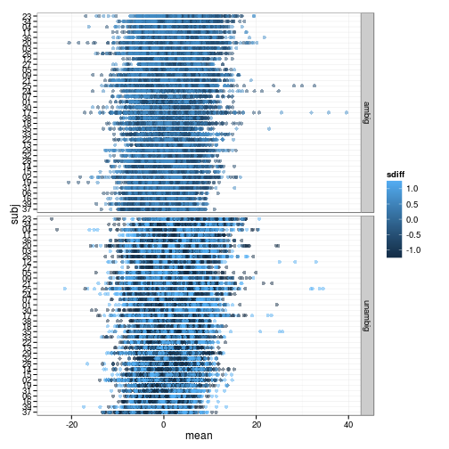

```r
library(ggplot2); theme_set(theme_bw())
mm <- transform(modeldata.n400,sdiff=cs.(sdiff),
                subj=reorder(subj,mean),
                item=reorder(item,mean))
mm0 <- subset(mm,select=c(mean,sdiff,ambiguity,subj,item))
## save("mm0",file="mm0.RData")
## L <- load("mm0.RData")
ggplot(mm0,aes(mean,subj,colour=sdiff))+geom_point(alpha=0.5)+
    facet_grid(ambiguity~.)
```

# lme4

```r
t.new <- system.time(sdiff.new <- lme4::lmer(form,
                                             data=modeldata.n400, REML=reml))
t.new
```

```
##    user  system elapsed
##   17.05    0.00   29.15
```

```r
print(summary(sdiff.new),correlation=FALSE)
```

```
## Linear mixed model fit by maximum likelihood  ['lmerMod']
## Formula: mean ~ ambiguity * c.(sdiff) + (1 + c.(sdiff) | item) + (1 +
##     c.(sdiff) | subj)
##    Data: modeldata.n400
##
##      AIC      BIC   logLik deviance df.resid
##   395942   396043  -197960   395920    69577
##
## Scaled residuals:
##    Min     1Q Median     3Q    Max
## -7.114 -0.619  0.005  0.621  9.321
##
## Random effects:
##  Groups   Name        Variance Std.Dev. Corr
##  item     (Intercept) 5.83e-01 0.763237
##           c.(sdiff)   2.28e-08 0.000151 -0.01
##  subj     (Intercept) 2.19e+00 1.481359
##           c.(sdiff)   2.16e+01 4.643984 0.41
##  Residual             1.70e+01 4.121273
## Number of obs: 69588, groups:  item, 60 subj, 37
##
## Fixed effects:
##                             Estimate Std. Error t value
## (Intercept)                 1.16e+00   2.64e-01     4.4
## ambiguityunambig            4.97e-01   3.12e-02    15.9
## c.(sdiff)                  -3.91e-04   7.63e-01     0.0
## ambiguityunambig:c.(sdiff)  3.82e-04   2.47e-05    15.5
```

Note we still get convergence warnings, even with lme4 1.1.7; this means they are probably **not** just false positives (so in this case they are a good thing!) Should have gotten scaling warnings too ???

```r
sdiff.new.scaled <- update(sdiff.new,formula=form.s)
```

# lme4.0

```r
t.old <- system.time(sdiff.old <- lme4.0::lmer(form,
                                               data=modeldata.n400, REML=reml))
t.old
```

```
##    user  system elapsed
##  53.483   0.604 103.935
```

```r
summary(sdiff.old)
```

```
## Linear mixed model fit by maximum likelihood
## Formula: form
##    Data: modeldata.n400
##     AIC    BIC  logLik deviance REMLdev
##  395191 395291 -197584   395169  395214
## Random effects:
##  Groups   Name        Variance Std.Dev. Corr
##  item     (Intercept) 1.76e-01 0.420014
##           c.(sdiff)   2.27e-08 0.000151 -0.012
##  subj     (Intercept) 1.23e+00 1.109455
##           c.(sdiff)   2.60e-08 0.000161 -0.330
##  Residual             1.70e+01 4.123918
## Number of obs: 69588, groups: item, 60; subj, 37
##
## Fixed effects:
##                             Estimate Std. Error t value
## (Intercept)                 1.16e+00   1.92e-01    6.05
## ambiguityunambig            4.97e-01   3.13e-02   15.90
## c.(sdiff)                  -3.88e-04   3.96e-05   -9.78
## ambiguityunambig:c.(sdiff)  3.82e-04   2.47e-05   15.45
##
## Correlation of Fixed Effects:
##             (Intr) ambgty c.(sd)
## ambigtynmbg -0.082
## c.(sdiff)   -0.213 -0.001
## ambgtyn:.()  0.000  0.001 -0.499
```

As stated, the important difference in the fixed effects is the size of the standard error in `c.(sdiff)` …

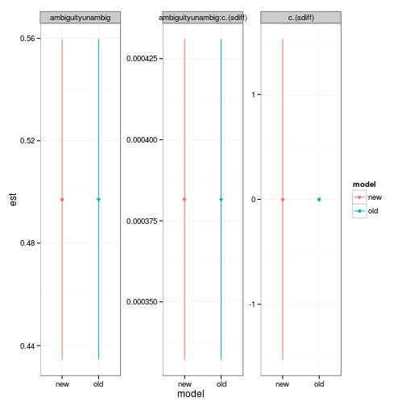

Compare theta values? (We can't get confidence intervals without profiling …)

# lme4 starting from lme4.0 results

```r
oldtheta <- getME(sdiff.old,"theta")
newtheta <- lme4::getME(sdiff.new,"theta")
sdiff.oldstart <- lme4::lmer(form,
                             data=modeldata.n400, REML=reml,
                             start=list(theta=getME(sdiff.old,"theta")))
sdiff.oldstart.nlminb <- lme4::lmer(form,
                             data=modeldata.n400, REML=reml,
                             start=list(theta=getME(sdiff.old,"theta")),
                             control=lmerControl(optimizer="optimx",
                             optCtrl=list(method="nlminb")))
```

We have an interesting problem here. New `lme4` calculates the deviance slightly differently; at \(\hat \theta_{\textrm{old}}\) it computes a deviance value about 29 units higher than `lme4.0`. If we start `lme4` from that point, we actually get a **worse** result (the deviance goes up by about 480 units!) — presumably we get thrown off by the initial displacement of the points from the starting value …

```r
sdiff.newdev <- update(sdiff.new,devFunOnly=TRUE)
devvec <- c(old=deviance(sdiff.old),new=deviance(sdiff.new),
            oldtheta.newdev=sdiff.newdev(oldtheta),
            oldstart=deviance(sdiff.oldstart),
            oldstart.nlminb=deviance(sdiff.oldstart.nlminb))
print(sort(devvec-min(devvec)),digits=3)
```

```
##             old oldstart.nlminb oldtheta.newdev        oldstart
##             0.0            16.6            28.8           481.7
##             new
##           751.4
```

```r
afurl <- paste0("https://raw.githubusercontent.com/lme4/",
                 "lme4/master/misc/issues/allFit.R")
eval(parse(text=getURL(afurl)))
```

```r
detach("package:lme4.0")
t.all <- system.time(sdiff.new.all <- allFit(sdiff.new))
```

```
## bobyqa. : [OK]
## Nelder_Mead. : [OK]
## optimx.nlminb : [OK]
## optimx.L-BFGS-B : [OK]
## nloptWrap.NLOPT_LN_NELDERMEAD : [OK]
## nloptWrap.NLOPT_LN_BOBYQA : [OK]
```

```r
sdiff.oldstart.all <- allFit(sdiff.oldstart)
```

```
## bobyqa. : [OK]
## Nelder_Mead. : [OK]
## optimx.nlminb : [OK]
## optimx.L-BFGS-B : [OK]
## nloptWrap.NLOPT_LN_NELDERMEAD : [OK]
## nloptWrap.NLOPT_LN_BOBYQA : [OK]
```

```r
library(lme4.0)
```

The bottom line is that trying lots of different optimizers doesn't do us any good in this case. Oddly enough, our Nelder-Mead implementation (which we have found to be generally less reliable than BOBYQA for big problems) turns out to do *best* of all the options (other than `lme4.0`) in this case …

```r
is.OK <- !sapply(sdiff.new.all,inherits,"error")
all.dev <- c(sapply(sdiff.new.all[is.OK],deviance),lme4.0=deviance(sdiff.old))
print(sort(all.dev-min(all.dev)),digits=4)
```

```
##                        lme4.0                  Nelder_Mead.
##                           0.0                         397.0
##                 optimx.nlminb                       bobyqa.
##                         513.1                         751.4
##     nloptWrap.NLOPT_LN_BOBYQA nloptWrap.NLOPT_LN_NELDERMEAD
##                         813.4                         910.1
```

Now try with scaled data:

```r
detach("package:lme4.0")
t.all <- system.time(sdiff.new.scaled.all <- allFit(sdiff.new.scaled))
```

```
## bobyqa. : [OK]
## Nelder_Mead. : [OK]
## optimx.nlminb : [OK]
## optimx.L-BFGS-B : [OK]
## nloptWrap.NLOPT_LN_NELDERMEAD : [OK]
## nloptWrap.NLOPT_LN_BOBYQA : [OK]
```

```r
library(lme4.0)
```

The code and data for this example can be found on [GitHub](https://github.com/palday/lme4-convergence)